# CS5702 W5 Lab Notebook

Martin Shepperd

27/10/2020

## Worksheet Contents

1. R Recap
2. Checking for quality with R
3. Exercise answers

##0. Worksheet Introduction

**Pre-requisites**

You should:

1. have studied the Week 4 seminar+lab worksheet
2. be familiar (listened to/read) the Week 5 Lecture “Data quality, cleaning and imputation”
3. be able to create and manipulate data frames
4. be able to apply straight forward summary statistics eg summary() and create basic plots eg scatterplots

This lab worksheet is organised as an RMarkdown file. You can **read** it. You can **run** the embedded R and you can **add** your own R. I suggest you save it as another file so, if necessary, you can revert to the original.

Whenever you click **Preview** in the RStudio menu it will render into nicely formatted html which you can look at it in the Viewing Window in RStudio or any web browser. You may find this easier to read, however, you must edit the .Rmd file, i.e., the RMarkdown in the Edit Pane if you want to make any changes.

Remember, you are encouraged to explore and experiment. Change something and see what happens!

## 1. R Recap

Let’s recap some of the more *useful* R functions you will have already come across.

For the next few exercises please use the built in data set “women”

```r
data("women")
```

```
There were 20 warnings (use warnings() to see them)
```

```r
View(women)
```

**Exercise 5.1:** We have emphasised the value of persisting with `ggplot2`.

Using {ggplot2} produce a scatter plot of height vs weight.

As a basic template you can start with this:

> ggplot(*, aes(x =* , y = ___) ) + geom_point()

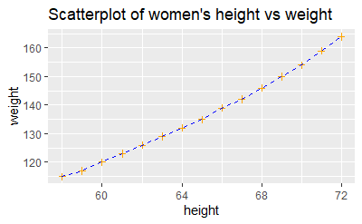

```r
ggplot(data = women, aes(x= height, y = weight)) +
  geom_point(shape = 3, color = "orange") +
  geom_line(linetype = "dashed", color = "blue") +
  ggtitle("Scatterplot of women's height vs weight")
```

**Exercise 5.2:**

You could add lines to join the data points using `geom_line()`. HINT: don’t forget to add a `+` between each additional ggplot function you want to add to the plot. NB If there isn’t a clear trend or the data do not naturally form a series joing the data points by lines may confuse rather than illuminate!

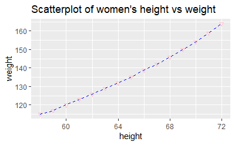

```r
ggplot(data = women, aes(x= height, y = weight)) +
  geom_point(shape = 6, color = "pink") +
  geom_line(linetype = "dashed", color = "blue") +
  ggtitle("Scatterplot of women's height vs weight")
```

```r
#This is a scatterplot where the lines have been added, and given a colour. There are various shaeps.
```

**Exercise 5.3:**

Add a suitable title using `ggtitle("????")`. Don’t forget the `+`.

**Exercise 5.4:**

Experiment with colour, line thickness and data point symbols. FOr an excellent tutorial and lots of guidance on ggplot2 see the [STDHA website](http://www.sthda.com/english/wiki/ggplot2-line-plot-quick-start-guide-r-software-and-data-visualization#create-line-plots-with-points)

**Exercise 5.5:**

You can assign your plots to an R object, either to further manipulate it or to store it and display at a later stage. Assign your scatterplot to a new R variable `plot1`. What can you do with it? What data type is it? See if you can modify it?

## 2. Checking for quality with R

### Dealing with missingness

Data quality and cleaning is principally concerned with NA. This special data type comes with some useful functions such as `is.na()`.

```r
# Create a numeric vector with the 4th
# item missing
numVector <- c(1, 3, 2, NA, 5)
is.na(numVector)
```

```
[1] FALSE FALSE FALSE  TRUE FALSE
```

or

```r
is.na(numVector[4])
```

```
[1] TRUE
```

**Exercise 5.6:**

Create your own character vector `charVector` with 10 elements. Make one of them (10th) empty i.e., "“. Test to see how `is.na()` treats these. Replace”" with NA programmatically.

```r
charvector = c( "A","B","C","D","E","F","G","H","J","")
charvector[10] = NA
is.na(charvector)
```

```
 [1] FALSE FALSE FALSE FALSE FALSE FALSE FALSE FALSE FALSE  TRUE
```

```r
charvector1 = c( "A","B","C","D","E","F","G","H","J","")
is.na(charvector1)
```

```
 [1] FALSE FALSE FALSE FALSE FALSE FALSE FALSE FALSE FALSE FALSE
```

**Exercise 5.7**

Typing lots of values into a vector manually can become tedious. So you can save time using the `rep()` function, e.g.,

```r
numVector <- rep(c(1, 2, 3), times = 5)
numVector
```

```
 [1] 1 2 3 1 2 3 1 2 3 1 2 3 1 2 3
```

Use this approach to make a 20 element character vector `charVector` which repeats the sequence “A”, “B”, NA. There are everal ways of achieving this but one option is to use the `length.out` parameter.

## 4. Exercise answers

Answers?

**5.1:** The package {ggplot2} is bundled with {tidyverse} so you probably have already installed it. You can check using `pkgs <- installed.packages(); View(pkgs)` which will list information about every installed package, version etc.

You only need install a package (onto your computer drive) *once*. After that you only need read it into memory each new R session with a `library()` function.

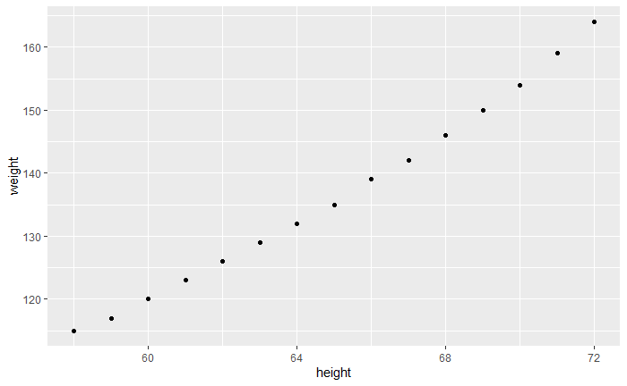

```r
# Produces a simple scatter plot of height vs weight for women
ggplot(data = women, aes(x = height, y = weight)) +
  geom_point()
```

**5.2:**

```r
ggplot(data = women, aes(x = height, y = weight)) +
  geom_point() +
  geom_line() +
  ggtitle("Scatterplot of Women's Height vs Weight")
```

[output not shown]

Don’t forget the `+` between geom_point() and geom_line().

**5.3:**

There are almost limitless possibilities!

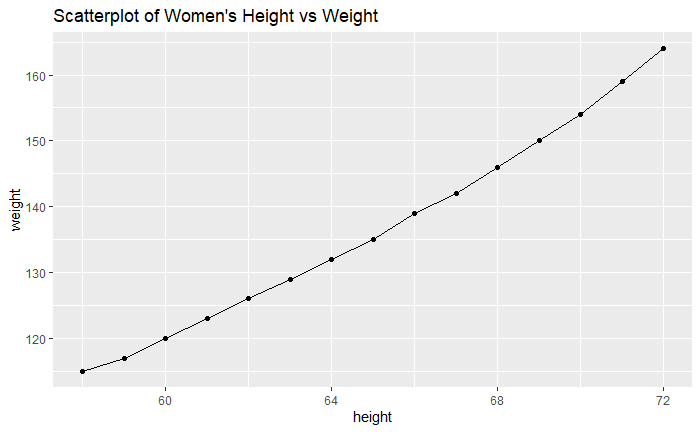

```r
ggplot(data = women, aes(x = height, y = weight)) +
  geom_point() +
  geom_line() +
  ggtitle("Scatterplot of Women's Height vs Weight")
```

**5.4:**

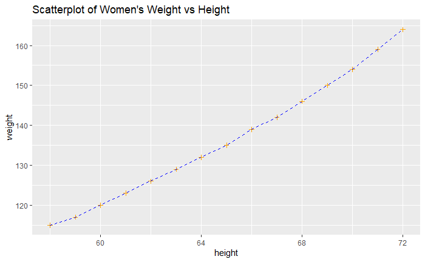

```r
ggplot(data = women, aes(x = height, y = weight)) +
  geom_point(shape=3, color = "orange") +
  geom_line(linetype = "dashed", color = "blue") +
  ggtitle("Scatterplot of Women's Weight vs Height")
```

NB The colour contrast isn’t great so these choices might not be optimal. Don’t get carried away!!

**5.5:**

You can assign your plots to an R object, either to further manipulate it or to store it and display at a later stage.

```r
plot1 <- ggplot(data = women, aes(x = height, y = weight)) +
  geom_point(shape=3, color = "orange") +
  geom_line(linetype = "dashed", color = "blue") +
  ggtitle("Scatterplot of Women's Weight vs Height")
```

**5.6**

```r
charVector <- c("A", "B", "C", "D", "E", "F", "G", "H", "I", "")
is.na(charVector)
```

```
 [1] FALSE FALSE FALSE FALSE FALSE FALSE FALSE FALSE FALSE FALSE
```

Note, "" is not treated as NA. So we need to change it.

```r
charVector[10] <- NA
is.na(charVector)
```

[output not shown]

**5.7**

```r
charVector <- rep(c("A", "B", NA), length.out = 20)
charVector
```

[output not shown]